# Detecting Volcanoes on Venus via Classification

### Logistic Regression:

As we did in classification section, we used both Marginal Screenign and Lasso to select important pixels. In this case, Marginal Screening gave us 250 important pixels based on best prediction accuracy and RMSE 0.5072927; Lasso selected 114 pixels gave us RMSE 0.6798163.

### Xgboost:

In performing prediction with xgboost, the tuning parameters were directly adopted from the xgboost model in the previous section.

### Neural network:

We implemented similar algorithm for Neural network as in the previous section.

```r
# Neural Network for
# number_volcano #

# convert the variable in to
# categorical variable
train_y_number <- to_categorical(train_y$Number.Volcanoes,
    num_classes = 6)
test_y_number <- to_categorical(test_y$Number.Volcanoes,
    num_classes = 6)

# model using convolutional
# layers and max pooling
model <- keras_model_sequential() %>%
    layer_conv_2d(filters = 8,
        kernel_size = c(3, 3),
        activation = "relu", input_shape = c(110,
            110, 1)) %>% layer_max_pooling_2d(pool_size = c(2,
    2)) %>% layer_conv_2d(filters = 16,
    kernel_size = c(3, 3), activation = "relu") %>%
    layer_max_pooling_2d(pool_size = c(2,
        2)) %>% layer_conv_2d(filters = 16,
    kernel_size = c(3, 3), activation = "relu") %>%
    layer_flatten() %>% layer_dense(units = 6,
    activation = "softmax")

# compile model using loss
# function 'categorical
# crossentropy' and metrics
# 'accuracy'
model %>% compile(optimizer = "adam",
    loss = "categorical_crossentropy",
    metrics = c("accuracy"))

# use 20% of the train data as
# validation data
model_ret <- model %>% fit(train_images,
    train_y_number, epochs = 30,
    batch_size = 32, validation_split = 0.2)
plot(model_ret)
# use the trained model to
# classify test set
results <- model %>% evaluate(test_images,
    test_y_number)
# classification probabilities
pred_results_number <- model %>%
    predict(test_images)
# classification results
pred_results_number_class <- model %>%
    predict_classes(test_images)
# accuracy and loss function
# results
acc_loss_number <- model %>% evaluate(test_images,
    test_y_number)
```

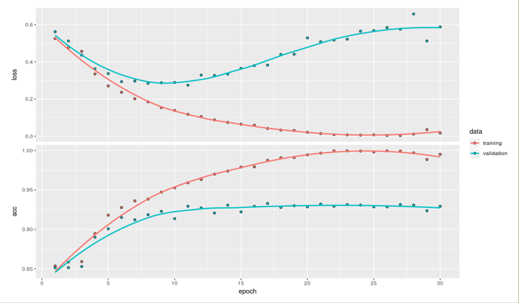

Neural Network to classify how many volcanoes in each image

The loss function and accuracy:

```
## $loss
## [1] 0.554538
##
## $acc
## [1] 0.9297732
```

## c. Variable selection methods

#### Marginal Screening

To apply Marginal Screening, we use for loop to model each pixels with outcome by using glm function, logistic regression. After sorting the p values from smallest to largest, we selected the top 400 pixels for classification and 250 for poisson prediction. The reason why we select top 400 and 250 pixels is that, after trying different number of top pixels, we found 400 pixels gave us highest prediction accuracy.

#### Variable selection methods comparison

We originally only applied Marginal Screening to logistic regression. But after realizing Lasso helped us selected variables as well, we tried both methods on logistic regression.

By looking at the pixels’ index, **figure 15** and **figure 17**, we found that the pixels selected by Marginal Screening focused between 4000-7000 for classification and between 5200 - 7000 for poisson prediction, which corresponds to the center of pictures; while pixels selected by lasso regression were more spread, as shown in **figure 16** and **figure 18**. Comparing these variable selection results to the variable importance in random forest, it is noted that trend of selected variables in Lasso corresponds to the variable importance in random forest.

By applying those two different selection methods, we found the accuracy of Lasso selection is higher for classification; while for Poisson prediction, Marginal Screening selection performs better.

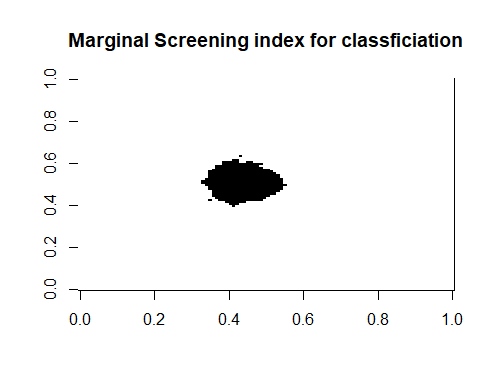

The Marginal Screening index for classification

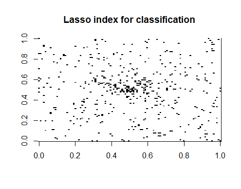

The Lasso index for classification

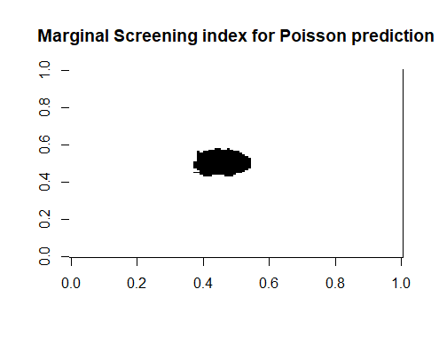

The Marginal Screening index for Poisson prediction

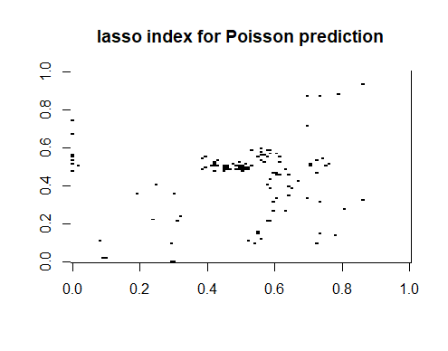

The Lasso index for Poisson prediction

Hence, for classification, lasso’s variable selection with more spread pixels made more sense because Marginal Screening’s centered selection might ignore some important pixels at the edges. For Poisson prediction, we prefer the Marginal Screening since the smaller number of pixels selected by Lasso regression would omit some important information.

Overall, we could conclude the variable selection criteria for this project is how much information the index can tell us without overfitting model.

## IV. CONCLUSION & DISCUSSION

Machine learning methods have long been popular in establishing models to faciliate humans in retreiving information from large datasets. One of the discussion topics in the venus image data, obtained through NASA’s Magellan spacecraft, is to contruct models in facilitating the identification of whether there are volcanoes or not, how many there are, and the confidence people have in identifying they are volcanoes. For our project, we aim in establishing prediction models in predicting the existance of volcano in image data as well as establishing prediction models in predicting how many volcanoes there are. As the daataset is rather unbalanced, with 85% of our image data having no volcanoes, we use the evaluation metric of AUC and F1 score as our prediction metric.

For the prediction of “predicting whether there is volcano or not”, our models show prediction results using AUC ranged from 0.8429 to 0.9680, using F1 score ranged from 0.9381 to 0.9747. When considering the best model chosen by either AUC or F1 score, it results in different models. For AUC, the best model is xgboost with AUC of 0.9680, whereas for F1 score the best model is neural network with F1 score of 0.9747. When comparing the confusion matrix of these two models, we notice that there are less false positive in xgboost where as there are less false negative in neural network.

Compared to structured data, the images used in this project are unstructured as volcanoes can occur in any pixels, this makes featuring difficult without performing principle component analysis. Models such as lasso, logistic, random forest, require more of predefined features. In this project, convolution neural network fits well in this kind of dataset as it considers local region of the datset.

It should be noted that, although the prediction result of Lasso regression is not as good as the advanced algorithms, this model took significantly less running time. If to take into account of running time, Lasso regression is still a good choice.

The limit of the models in this project is that, due to large parameter and sample size. Tuning advanced models such as random forest, xgboost, and neural network takes a lot of time. The tuning done in this project could be more fined tuned in the future. When predicting the number of volcanoes, parameters in xgboost and neural network were directly used from the previous model, therefore these models could also be further tuned in the future.

In addition, dimension reduction methods such as single value decomposition was not performed. As image data are unstructered and image data of venus may include several noises, performing dimension reduction may have improvment in the prediction. As the dataset in this project was quite large, we were not able to use `svd` function to perform dimension reduction. For future improvement of this project, we could try faster packages such as `irlba` package to perform partial singular value decompositions and see if there is improvement in our model.

## V. REFERENCES

Burl, M.C., Asker, L., Smyth, P. et al. Learning to Recognize Volcanoes on Venus. Machine Learning (1998) 30: 165. https://doi.org/10.1023/A:1007400206189

Kumar, A., Finding Volcanoes On Venus. https://www.kaggle.com/amantheroot/finding-volcanoes-on-venus

King, H., Volcanoes on Venus. https://geology.com/stories/13/venus-volcanoes/